## Liquor Sales in Iowa

This dataset https://data.iowa.gov/Sales-Distribution/2019-Iowa-Liquor-Sales/38x4-vs5h contains the spirits purchase information of Iowa Class “E” liquor licensees by product and date of purchase for 2019. The dataset can be used to analyze total spirits sales in Iowa of individual products at the store level.

**Submission instructions**: Create a folder named `ds202_hw5`, and name the RMarkDown file including your solutions `hw5.Rmd` under this folder. For the submission, create a GitHub repository named `ds202_hw5` under your GitHub account, and push both `hw5.Rmd` and the knitted `hw5.html` before the deadline. I will assume you use the same GitHub username as for your HW4 submission. The latest version of your homework appearing on GitHub before the deadline is graded. *It is crucial to follow the exact folder structure and file names*, so that your homework can be reproduced and graded by an automated script. This homework is **due on April 10** by 11:59 pm.

1. The complete dataset is too large. Download and import the alcohol sales data for Ames only:
1. Go to https://data.iowa.gov/Sales-Distribution/2019-Iowa-Liquor-Sales/38x4-vs5h
2. Click Filter – Filter – Go advanced now
3. Add a New Filter Condition: City is Ames.
4. Export – CSV – Download
5. Use `readr::read_csv` to import.

```r
library(tidyverse)
library(lubridate)
library(dplyr)
options(digits=9)
data<-readr::read_csv("2019_Iowa_Liquor_Sales.csv")
```

2. Data cleaning:
1. extract geographic latitude and longitude from the variable `Store Location`
2. make sure the variables are in the correct type, by converting incorrect variable types.
3. extract year, month and day from the variable `Date` as separate columns.

```r
#clean <-data%>%separate('Store Location',c('a','b'))%>%drop_na()
#clean <-data%>%mutate('Store Location'=gsub("POINT ","",`Store Location`))%>%drop_na()
clean <-data%>%mutate('Store Location'=gsub("POINT ","",`Store Location`))%>%mutate('Store Location'=gsub("[()]","",`Store Location`))%>%separate('Store Location',into=c("Latitude","Longitude"),sep=" ")%>%drop_na()

clean$Latitude<-as.numeric(clean$Latitude)
clean$Longitude<-as.numeric(clean$Longitude)
clean$`Vendor Number`<-as.numeric(clean$`Vendor Number`)
clean$Date<-mdy(clean$Date)
clean$Year<-year(clean$Date)
clean$Month <- month(clean$Date)
clean$Day<-day(clean$Date)
str(clean)
```

```
## Classes 'tbl_df', 'tbl' and 'data.frame':    48175 obs. of  28 variables:
##  $ Invoice/Item Number  : chr  "INV-16835000019" "INV-16886300007" "INV-17377700173" "INV-17376600028" ...
##  $ Date                 : Date, format: "2019-01-09" "2019-01-11" ...
##  $ Store Number         : num  4509 5187 4129 3973 2501 ...
##  $ Store Name           : chr  "AJ'S LIQUOR II" "Kwik Stop Liquor & Groceries Ames" "Cyclone Liquors" "MMDG SPIRITS / Ames" ...
##  $ Address              : chr  "2515 Chamberlain" "125 6th ST" "626 Lincoln Way" "126A Welch Ave" ...
##  $ City                 : chr  "Ames" "Ames" "Ames" "Ames" ...
##  $ Zip Code             : num  50010 50010 50010 50014 50010 ...
##  $ Latitude             : num  -93.7 -93.6 -93.6 -93.7 -93.6 ...
##  $ Longitude            : num  42 42 42 42 42 ...
##  $ County Number        : num  85 85 85 85 85 85 85 85 85 85 ...
##  $ County               : chr  "STORY" "STORY" "STORY" "STORY" ...
##  $ Category             : num  1031200 1032100 1081400 1081300 1081200 ...
##  $ Category Name        : chr  "American Flavored Vodka" "Imported Vodkas" "American Schnapps" "American Cordials & Liqueur" ...
##  $ Vendor Number        : num  259 35 65 434 216 420 115 434 434 461 ...
##  $ Vendor Name          : chr  "Heaven Hill Brands" "BACARDI USA INC" "Jim Beam Brands" "LUXCO INC" ...
##  $ Item Number          : num  36606 34359 82787 76487 80447 ...
##  $ Item Description     : chr  "Deep Eddy Orange" "Grey Goose" "Dekuyper Buttershots" "Paramount Amaretto" ...
##  $ Pack                 : num  12 12 12 12 6 24 6 12 6 12 ...
##  $ Bottle Volume (ml)   : num  750 200 1000 1000 750 200 1750 750 1750 750 ...
##  $ State Bottle Cost    : num  9 5 7.87 4.05 10 6.24 13 5.48 7.17 9.01 ...
##  $ State Bottle Retail  : num  13.5 7.5 11.81 6.08 15 ...
##  $ Bottles Sold         : num  2 12 1 7 6 3 6 2 6 12 ...
##  $ Sale (Dollars)       : num  27 90 11.8 42.6 90 ...
##  $ Volume Sold (Liters) : num  1.5 2.4 1 7 4.5 0.6 10.5 1.5 10.5 9 ...
##  $ Volume Sold (Gallons): num  0.39 0.63 0.26 1.84 1.18 0.15 2.77 0.39 2.77 2.37 ...
##  $ Year                 : num  2019 2019 2019 2019 2019 ...
##  $ Month                : num  1 1 2 2 2 2 2 2 2 2 ...
##  $ Day                  : int  9 11 6 6 6 13 13 13 13 27 ...
```

3. First overview:
1. Plot a scatterplot of lat and long of store locations.

[figure not shown]

```r
temp<-clean%>%distinct(`Store Name`,`Latitude`,`Longitude`)
temp%>%ggplot(aes(x=Latitude,y=Longitude,color=`Store Name`))+geom_point()+xlab("Latitude")+ylab("Longitude")+ggtitle("Longitude and Latitude of store location")
```

b. Provide a visual breakdown of the liquor category (by `Category Name`). Include volume sold in the breakdown.

[figure not shown]

```r
clean%>%ggplot(aes(x=`Category Name`,count=`Volume Sold (Liters)`))+geom_histogram(stat = "count")+coord_flip()+theme(axis.text.y = element_text(size = 6))+ylab("Volume Sold (Liters)")+ggtitle("Volume Sold in Category Name")
```

4. Find the daily sales liquor sales in Ames in 2019. Summarize the number of sales, volume of liquor sold, and amount of money spent.

```r
summary(clean$`Bottles Sold`)
```

```
##     Min.  1st Qu.   Median     Mean  3rd Qu.     Max.
##    1.000    2.000    6.000   10.332   12.000 1488.000
```

```r
summary(clean$`Volume Sold (Liters)`)
```

```
##    Min. 1st Qu.  Median    Mean 3rd Qu.    Max.
##    0.02    1.50    4.80   10.04   10.50 1890.00
```

```r
summary(clean$`Sale (Dollars)`)
```

```
##      Min.   1st Qu.    Median      Mean   3rd Qu.      Max.
##     2.700    36.000    81.540   153.045   162.000 22266.000
```

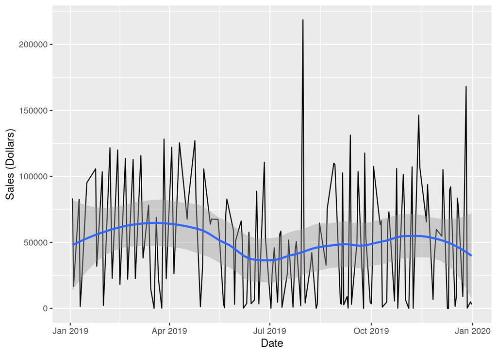

```r
temp<-clean%>%filter(Year==2019)%>%group_by(Date)%>%summarize(bottles_sold=sum(`Bottles Sold`),volume_liters=sum(`Volume Sold (Liters)`),Sales=sum(`Sale (Dollars)`))
temp%>%ggplot(aes(x=Date,y=Sales))+geom_line()+geom_smooth(span=1/2)+ylab("Sales (Dollars)")
```

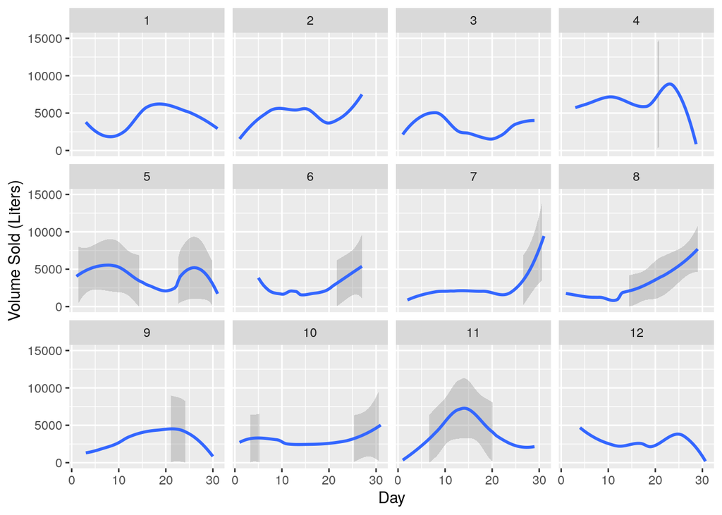

```r
temp<-clean%>%filter(Year==2019)%>%group_by(Month,Day)%>%summarize(bottles_sold=sum(`Bottles Sold`),volume_liters=sum(`Volume Sold (Liters)`),Sales=sum(`Sale (Dollars)`))
temp%>%ggplot(aes(x=Day,y=volume_liters))+geom_smooth()+facet_wrap(~Month)+ylim(0,15000)+ylab("Volume Sold (Liters)")
```

Note: your submission is supposed to be fully reproducible, i.e. the TA and I will ‘knit’ your submission in RStudio.